# Preliminary evaluation of alternative sablefishapportionment strategies

#### US longline fishery index (RPW)

The OM (‘true’) and EM estimates for the longline fishery abundance index are shown below for each apportionment method.

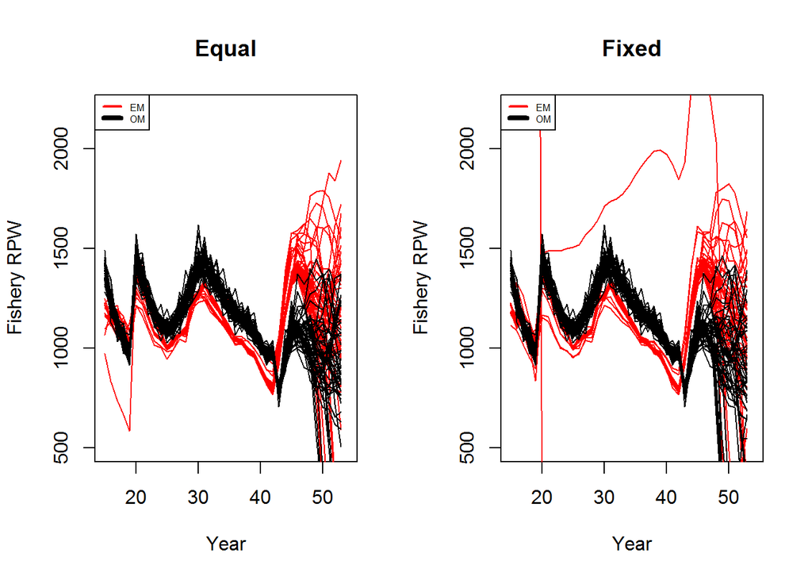

Figure 23. US fixed gear fishery index for all years and simulations. Note that the forward projecting period begins in year 44 (2019), prior to that the Conditioning period is deterministic.

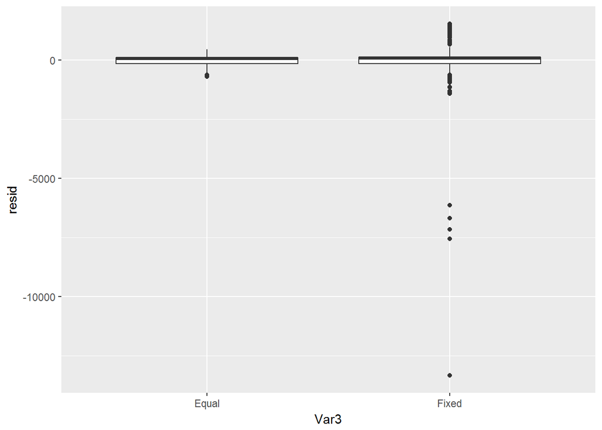

Figure 24. These boxplots are showing the residuals between the EM and OM for EM terminal year of the fishery index (2029) for all simulations and each apportionment method.

### Recruitment

The min and max OM recruitment values (over all simulations and years) are:  
Min: 0.6363891  
Max: 50

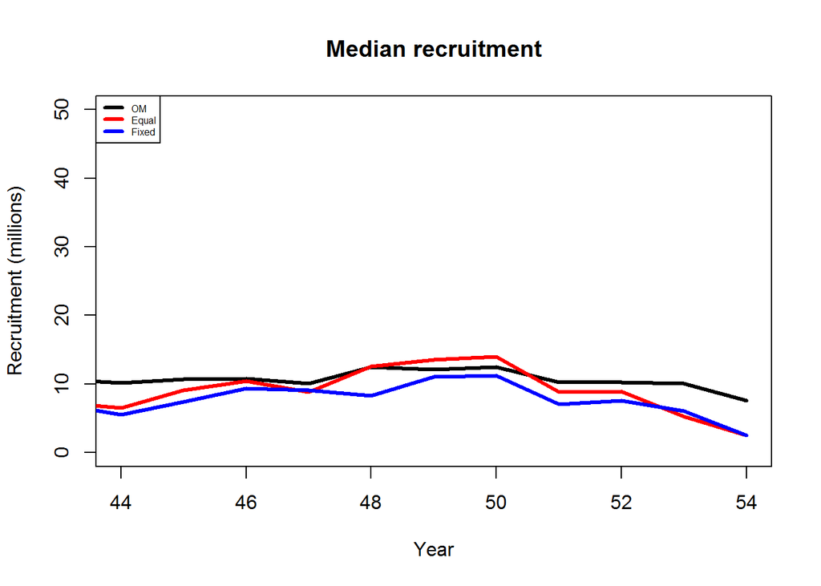

Figure 25. Median EM estimated recruitment and the OM recruitment, across all simulations. Recall that OM recruitment (black line) is the same across apportionment methods and it is only the estimated recruitment from the EM for each apportionment method that will vary.

Then look at the mean EM and mean OM recruitment draws by apport scenario. There is something very wrong with these EM mean values (right now).

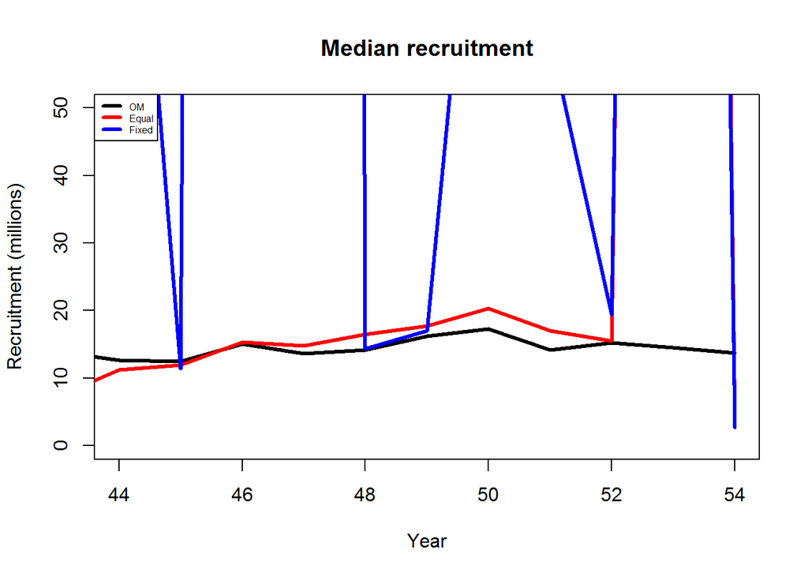

Figure 26. Mean EM estimated recruitment and the OM recruitment, across all simulations. Recall that OM recruitment (black line) is the same across apportionment methods and it is only the estimated recruitment from the EM for each apportionment method that will vary.

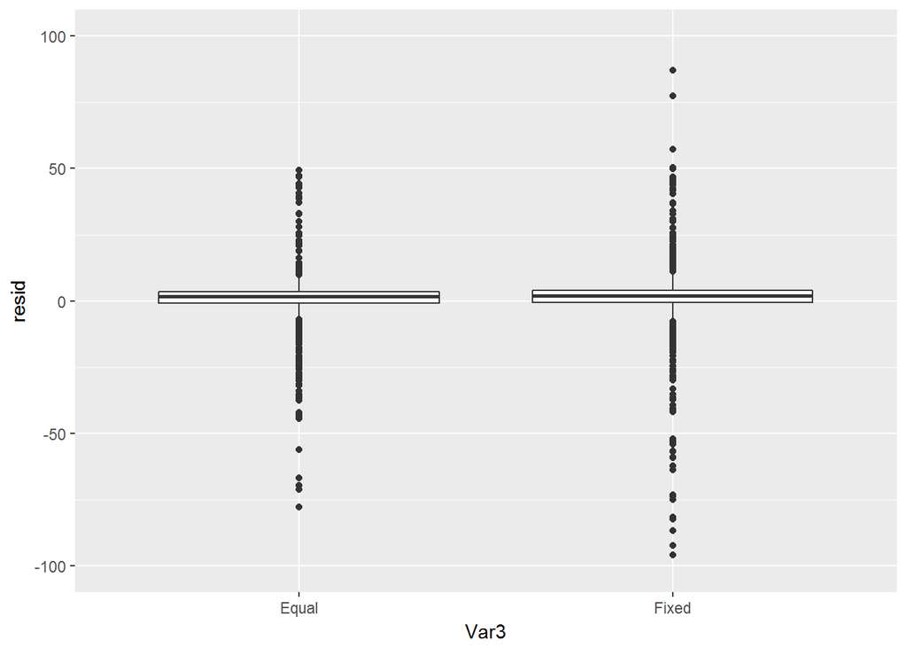

Figure 27. This shows the OM-EM residual distribution for each apportionment method.

### SSB time series

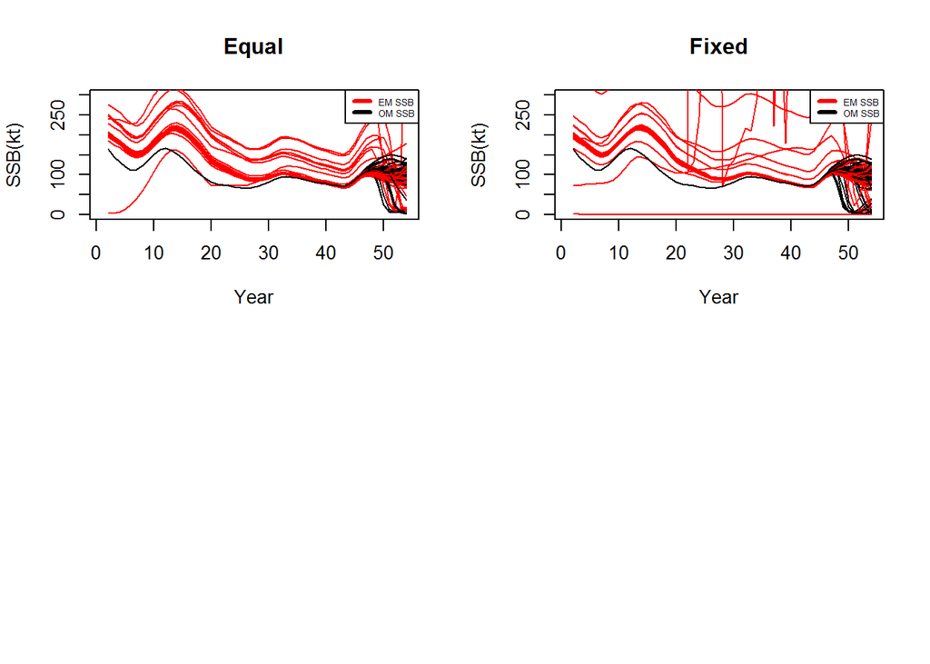

SSB residuals  
These are the OM ssb - EM ssb residuals for all years and simulations, for each apportionment method.

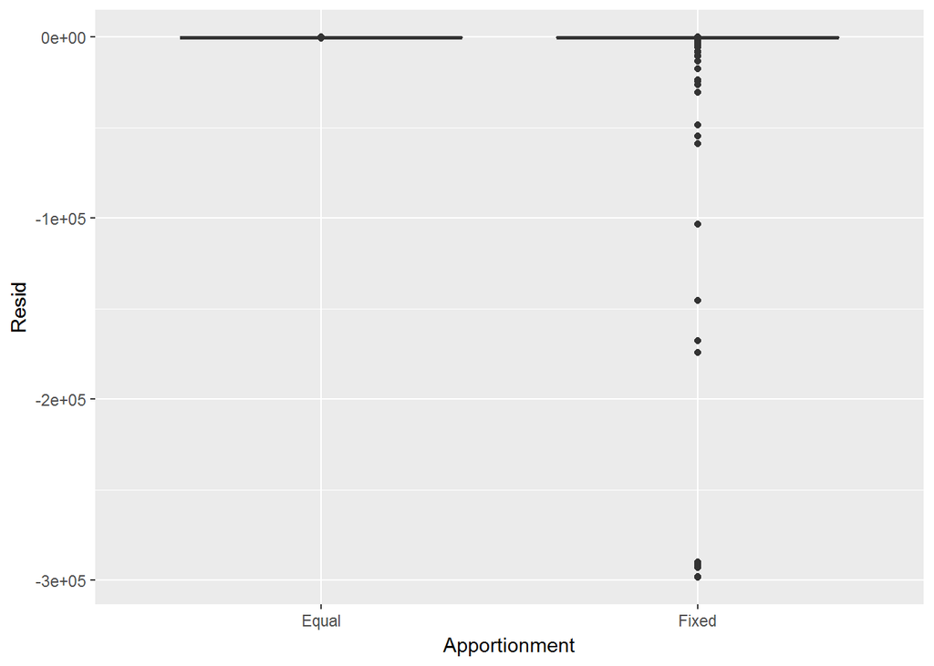

Figure 29. This shows the OM-EM SSB residual distribution for each apportionment method.

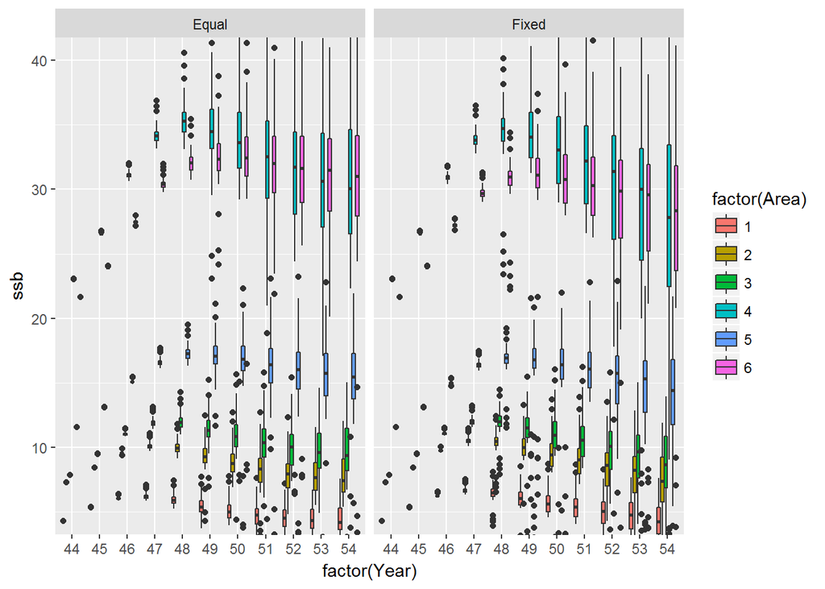

Figure 30. Spawning stock biomass (kt) for the OM population by area and apportionment method.

# Appendix 1 - additional information and figures

### Apportionment specifics

Several apportionment methods have fixed or input specifications.  
For ‘Fixed’ apportionment, the proportions of ABC by area (in order Bering Sea, Aleutian Islands, Western GOA, Central GOA, West Yakutat, East Yakutat/SEO) are: 10%, 13%, 11%, 34%, 11%, 21%.

For ‘Equilibrium’ apportionment, the proportions of ABC under the stationary distribution of the movement rates (areas in same order as above): 9%, 14%, 13%, 27%, 14%, 23%.

For ‘A_L.mat’ apportionment, the age at 50% maturity is assumed to be age-5 (it is really closer to age 5.5 but we cannot use half ages).

### Selectivity

There are no length comps in the EM and only age comps for 1999 forward for the longline survey and the fixed gear fishery. As such, there’s no data informing selectivity for the pre-IFQ fishery or trawl fishery in the EM. However, figures below show EM estimates and OM values for selectivity for these fisheries.  
#### Longline fishery Pre-IFQ selectivity

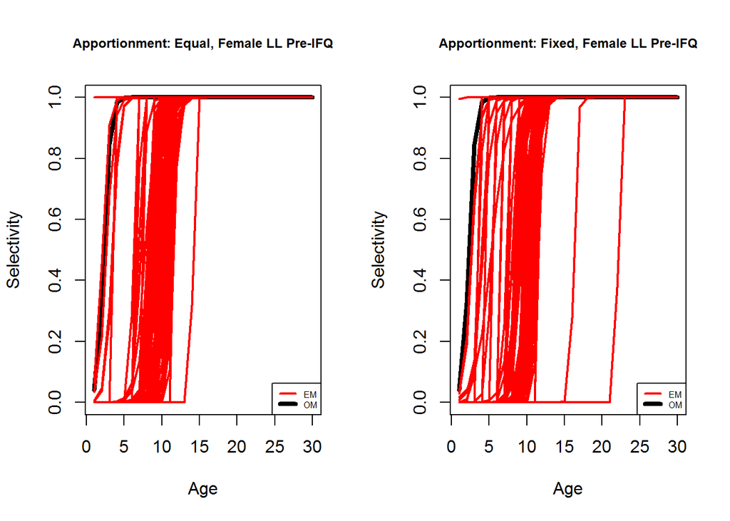

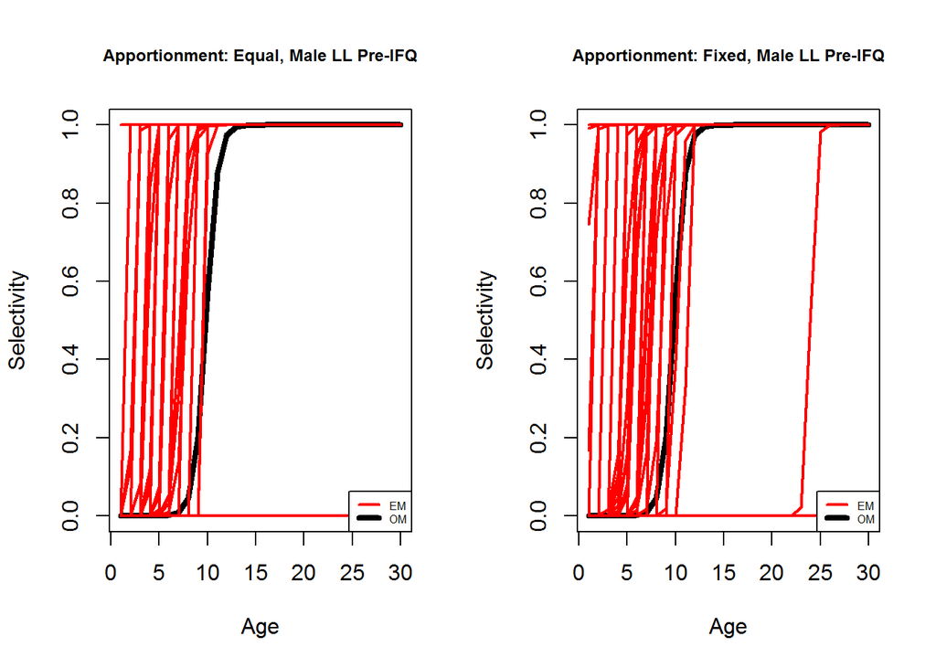

#### Trawl fishery

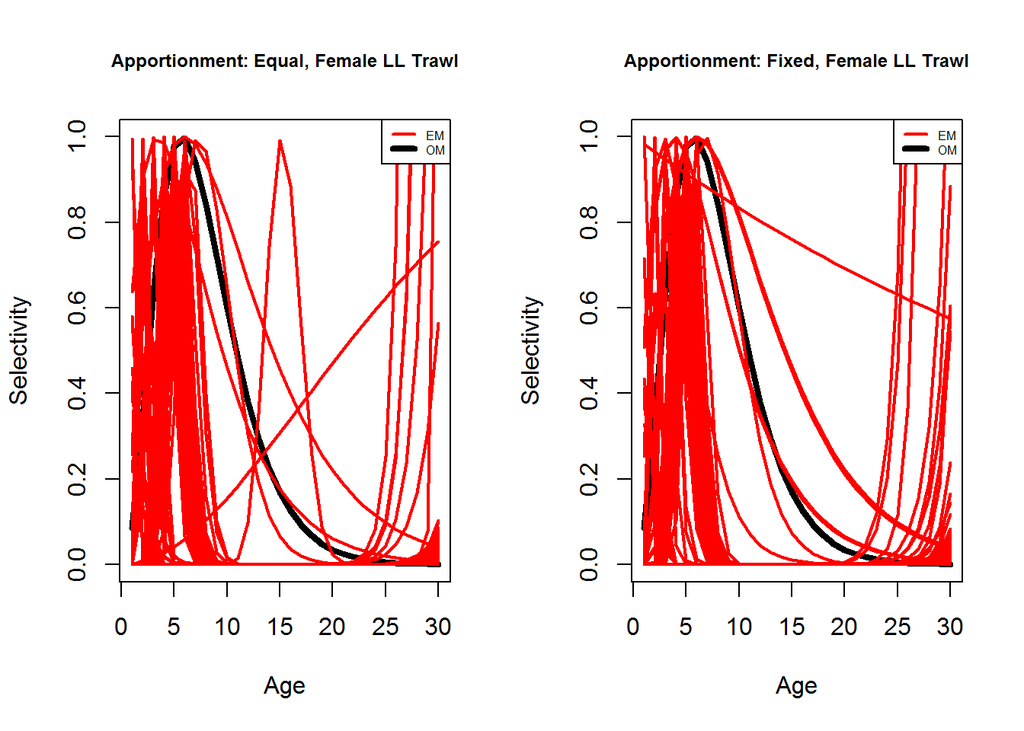

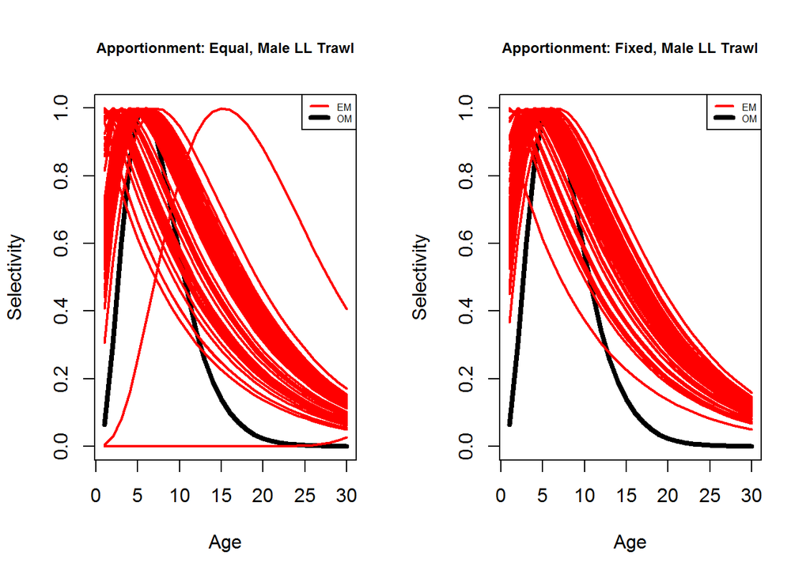

Recruitment from the Management EM is used during the conditioning period for the OM, and it has a small amount of autocorrelation (in its ‘uncorrected’ form, before we reduce 2014 from 150 million recruits to 50 million recruits). For the simulations shown here, we have used an autocorrelation parameter of 0.2 when generating OM recruitment. With the 2014 high recruitment removed, there does not appear to be any appreciable autocorrelation in recruitment:

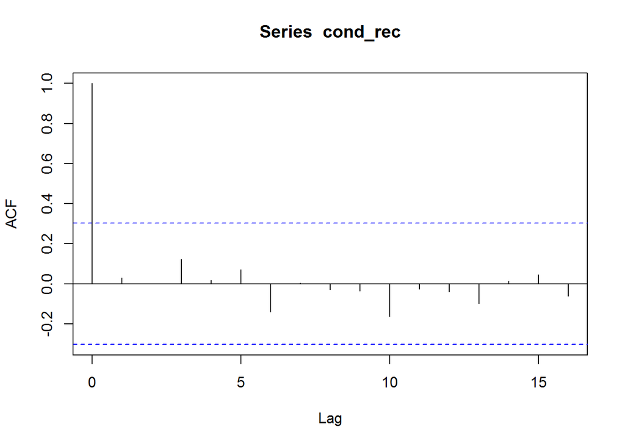